# Table of Contents

## Tables

Here is what the code looks like with the table the rendered code creates below it.

```
| Step  1 | Step 2 | Step 3 | Step 4 | Step 5 |
|---------|--------|--------|--------|--------|
|Acquire  |Prep    |Explore |Model   |Evaluate|
```

| Step 1 | Step 2 | Step 3 | Step 4 | Step 5 |
| --- | --- | --- | --- | --- |
| Acquire | Prep | Explore | Model | Evaluate |

Customize the alignment of your table with the addition of a colon in your hyphen strings.

- `:--- = left align`
- `---: = right align`
- `:---: = centered`

## Code Styling

### Monospace Font for Code Snippets

`You can use the grave accent on the upper left of your keyboard to surround code snippets. They will display in monospace font like this with a gray background instead of executing. Use this when you are embedding small snippets of code in your text. If you have a code block, see the syntax below for Code and Syntax Highlighting.`

[figure not shown]

### Code and Syntax Highlighting

When you are displaying more than a word or phrase of code, this is a great way to handle blocks of code. You can see the block begins and ends with three grave accent marks. In this example, my code is Python, so I identify my language on the first line. This allows the notebook to display proper highlighting like you would see in a text editor. Super clean.

````
```python
def cool_code(code):
    print(code)
```
````

```
def cool_code(code):
    print(code)
```

## Image Styling

### Drag and Drop Images

You can simply drag and drop or copy and paste an image into your Jupyter notebook. I have run into issues when I embed more than one image in a notebook by using drag and drop, so I prefer to imbed my images using the syntax you see below. Here you see the code and the rendered code below it displaying the image. The text in the brackets is optional, but it's nice to include a description.

```
![innovation_mind_map](https://i.pinimg.com/originals/2c/65/e9/2c65e919057ff833bfeaa8c513b4ba52.gif)
```

[figure not shown]

[output not shown]

### Anchor Links

Embed an internal link to a section of your own notebook. This is great to quickly jump from one section of a large notebook to another.

1. Add a tag above the section you want to link. This tag identifier is called section_1, but you could call it whatever you want (without spaces, use underscore if you want).

`<a id='section_1'></a>`

1. Add the name you want displayed for the link in brackets, and the section tag proceded by a pound sign.

`For more details, see [Section 1](#section_1)`

### Embed an External Link in Your Text

```
The *quick*, brown fox jumped **over** the lazy [dog](https://en.wikipedia.org/wiki/Dog).
```

The *quick*, brown fox jumped **over** the lazy [dog](https://en.wikipedia.org/wiki/Dog).

### Buttons, Take Me Away!

```
<button class="button-save large">[Codeup Data Science](https://codeup.com/ds-course-catalog/)</button>
```

```
<button class="button-save large">[w3docs](https://w3docs.com)</button>
```

### Image Button Links

If you use an image saved locally, it will not display in your html file. You need the image address.

```
[![alt text](image address)](target_url)
```

[output not shown]

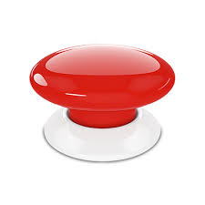

[output not shown]

[figure not shown]

[output not shown]

[figure not shown]

## Interactive Widgets Resource

Want to use interactive widgets to make buttons and other amazing interactive object in your notebook? [Here's](https://medium.com/@jdchipox/how-to-interact-with-jupyter-33a98686f24e) a good place to start.

## Markdown Resources

This is a nice, simple rundown of [markdown formatting](https://www.ibm.com/support/knowledgecenter/SSHGWL_1.2.3/analyze-data/markd-jupyter.html)

This is a nice [Basic Syntax](https://www.markdownguide.org/basic-syntax/) Guide that shows Markdown and HTML versions side-by-side.

Who doesn't love a nice, simple [cheatsheet](https://www.markdownguide.org/cheat-sheet/)

## LaTeX Resources

This [cheatsheet](https://www.math.ubc.ca/~pwalls/math-python/jupyter/latex/) for using LaTeX in your notebook can save you a lot of time!

This [one](https://kapeli.com/cheat_sheets/LaTeX_Math_Symbols.docset/Contents/Resources/Documents/index) is GREAT, too. Just remember that you need to surround the text with dollar signs like below.

```
markdown
$\Omega$
```

$\Omega$